# Pauzinhos Japoneses!

Alguns pesquisadores decidiram investigar o comprimento ótimo de palitinhos para crianças e adultos. Eles inventaram uma medida de quão efetivo um par de pauzinhos é chamado "Desempenho de Pinçar Comida". Esta medida é determinada pelo número de amendoins pinçados e colocados dentro de um copo (PPPC).

### Uma investigação para determinar o comprimento ótimo de palitinhos.

[Link para o Resumo e o Artigo (em inglês)](http://www.ncbi.nlm.nih.gov/pubmed/15676839)  
*o resumo abaixo foi adaptado do link*

Os palitinhos são uma das ferramentas manuais mais simples e populares desenvolvidos pelo ser humano, mas que não tinham sido investigados anteriormente por [ergonomistas](https://www.google.com/search?q=ergonomists). Dois estudos em laboratório foram conduzidos nessa pesquisa, utilizando um [projeto de bloco completo randomizado](http://dawg.utk.edu/glossary/whatis_rcbd.htm) para avaliar os efeitos do comprimento dos palitinhos no desempenho de servir comida de adultos e crianças. Trinta e um calouros universitários, do sexo masculino, e 21 crianças dos primeiros anos do ensino fundamental serviram como participantes do experimento para testar o comprimento de palitinhos dos tamanhos 180, 210, 240, 270, 300 e 330 mm. O resultado mostrou que o desempenho de pinçar comida foi significativamente afetado pelo comprimento dos palitinhos, e os palitinhos de 240 e 180 mm foram ótimos para adultos e crianças, respectivamente. Baseado nesses achados, os pesquisadores sugerem que as famílias com crianças providenciassem ambos palitinhos de 240 e 180 mm. Além disso, restaurantes poderiam providenciar palitinhos de 240 e 180 mm, considerando o trade-off entre ergonomia e custo.

### Para o resto deste projeto, responda todas as perguntas baseando-se somente na análise do experimento com os trinta um alunos calouros universitários.

Faça o download do [conjunto de dados dos adultos](https://www.udacity.com/api/nodes/4576183932/supplemental_media/chopstick-effectivenesscsv/download), depois responda as seguintes questões baseadas no resumo e no conjunto de dados.

**Se você der um duplo clique nesta célula**, você verá que o texto mudou e que toda a formatação foi removida. Isso permite que você edite esse bloco de texto. Esse bloco de texto foi escrito utilizando [Markdown](http://daringfireball.net/projects/markdown/syntax), que é uma maneira de formatar o texto utilizando cabeçalhos, links, itálicos e outra opções. Você aprenderá mais sobre o Markdown posteriormente no Programa Nanodegree. Para mostrar o texto formatado pressione shift + enter ou shift + return.

#### 1. Qual é a variável independente nesse experimento?

A variável independente do experimento é o tamanho do Hashi (Chopstick Lenght).

#### 2. Qual é a variável dependente do experimento

A variável dependente do experimento é o "Desempenho de Pinçar Comida" (Food Pinching Efficiency).

#### 3. Como a variável dependente é operacionalmente definida?

A variável dependente (Desempenho de Pinçar Comida) é operacionalmente definida pelo número de amendoins pinçados e colocados dentro de um copo (PPPC).

#### 4. Baseado na descrição do experimento e no conjunto de dados, cite duas variáveis que você sabe que eram controladas.

O sexo (masculino) dos trinta e um calouros universitários e a escolaridade (primeiros anos do ensino fundamental) das 21 crianças foram variáveis controladas neste experiemnto.

Uma das grandes vantagens de utilizar o iPython Notebook é que você pode documentar sua análise de dados utilizando código, adicionando comentários ao código, ou até mesmo adicionando blocos de texto utilizando o Markdown. Esses Notebooks permitem que você colabore com outras pessoas e compartilhe seu trabalho. Por enquanto, vamos ver alguns códigos que geram estatísticas.

```python
import pandas as pd

# pandas é uma biblioteca para manipulação e anáise de dados
# geralmente usamos nomes mais curtos para as bibliotecas.Pabdas é geralmente abreviada para pd
# tecle shift + enter para rodar esta célula ou bloco de código
```

```python
path = r'~/Downloads/chopstick-effectiveness.csv'
# Mude o caminho para o local onde o arquivo chopstick-effectiveness.csv foi baixado em seu computador
# se você receber um erro quando estiver rodando este bloco de código, certifique-se que o arquivo chopstick-effectiveness.csv
# está localizado no diretório acima.
dataFrame = pd.read_csv(path)
dataFrame
```

|  | Food.Pinching.Efficiency | Individual | Chopstick.Length |
| --- | --- | --- | --- |
| 0 | 19.55 | 1 | 180 |
| 1 | 27.24 | 2 | 180 |
| 2 | 28.76 | 3 | 180 |
| 3 | 31.19 | 4 | 180 |
| 4 | 21.91 | 5 | 180 |
| 5 | 27.62 | 6 | 180 |
| 6 | 29.46 | 7 | 180 |
| 7 | 26.35 | 8 | 180 |
| 8 | 26.69 | 9 | 180 |
| 9 | 30.22 | 10 | 180 |
| 10 | 27.81 | 11 | 180 |
| 11 | 23.46 | 12 | 180 |
| 12 | 23.64 | 13 | 180 |
| 13 | 27.85 | 14 | 180 |
| 14 | 20.62 | 15 | 180 |
| 15 | 25.35 | 16 | 180 |
| 16 | 28.00 | 17 | 180 |
| 17 | 23.49 | 18 | 180 |
| 18 | 27.77 | 19 | 180 |
| 19 | 18.48 | 20 | 180 |
| 20 | 23.01 | 21 | 180 |
| 21 | 22.66 | 22 | 180 |
| 22 | 23.24 | 23 | 180 |
| 23 | 22.82 | 24 | 180 |
| 24 | 17.94 | 25 | 180 |
| 25 | 26.67 | 26 | 180 |
| 26 | 28.98 | 27 | 180 |
| 27 | 21.48 | 28 | 180 |
| 28 | 14.47 | 29 | 180 |
| 29 | 28.29 | 30 | 180 |
| ... | ... | ... | ... |
| 156 | 26.18 | 2 | 330 |
| 157 | 25.93 | 3 | 330 |
| 158 | 28.61 | 4 | 330 |
| 159 | 20.54 | 5 | 330 |
| 160 | 26.44 | 6 | 330 |
| 161 | 29.36 | 7 | 330 |
| 162 | 19.77 | 8 | 330 |
| 163 | 31.69 | 9 | 330 |
| 164 | 24.64 | 10 | 330 |
| 165 | 22.09 | 11 | 330 |
| 166 | 23.42 | 12 | 330 |
| 167 | 28.63 | 13 | 330 |
| 168 | 26.30 | 14 | 330 |
| 169 | 22.89 | 15 | 330 |
| 170 | 22.68 | 16 | 330 |
| 171 | 30.92 | 17 | 330 |
| 172 | 20.74 | 18 | 330 |
| 173 | 27.24 | 19 | 330 |
| 174 | 17.12 | 20 | 330 |
| 175 | 23.63 | 21 | 330 |
| 176 | 20.91 | 22 | 330 |
| 177 | 23.49 | 23 | 330 |
| 178 | 24.86 | 24 | 330 |
| 179 | 16.28 | 25 | 330 |
| 180 | 21.52 | 26 | 330 |
| 181 | 27.22 | 27 | 330 |
| 182 | 17.41 | 28 | 330 |
| 183 | 16.42 | 29 | 330 |
| 184 | 28.22 | 30 | 330 |
| 185 | 27.52 | 31 | 330 |

186 rows × 3 columns

Vamos fazer um cálculo de estatística básico com os dados utilizando código! Execute o bloco de código abaixo para calcular a média da "Eficiência de Pinçar Comida" para os 31 participantes e todos os comprimentos de palitinhos.

```python
dataFrame['Food.Pinching.Efficiency'].mean()
```

```
25.00559139784947
```

Esse número é útil, mas esse número não nos dá ciência de qual dos comprimentos de palitinhos tiveram o melhor desempenho para trinta calouros universitários, do sexo masculino. Vamos separar os dados pelo tamanho dos palitinhos. O próximo bloco de código vai gerar a média da "Eficiência de Pinçar Comida" para cada comprimento de palitinhos. Execute o bloco de código abaixo.

```python
meansByChopstickLength = dataFrame.groupby('Chopstick.Length')['Food.Pinching.Efficiency'].mean().reset_index()
meansByChopstickLength

# reset_index() muda o Chopstick.Length de um índice para uma coluna
# Em vez do índice ser o comprimento dos palitinhos, o índice serão os números em linha 0, 1, 2, 3, 4, 5.
```

|  | Chopstick.Length | Food.Pinching.Efficiency |
| --- | --- | --- |
| 0 | 180 | 24.935161 |
| 1 | 210 | 25.483871 |
| 2 | 240 | 26.322903 |
| 3 | 270 | 24.323871 |
| 4 | 300 | 24.968065 |
| 5 | 330 | 23.999677 |

#### 5. Qual comprimento dos palitinhos é o melhor para o grupo de trinta e um estudantes calouros universitários, do sexo masculino?

O comprimento de palitinho que apresentou maior eficiência para o grupo de trinta e um estudantes caloros universitários do sexo masculino foi 240 mm.

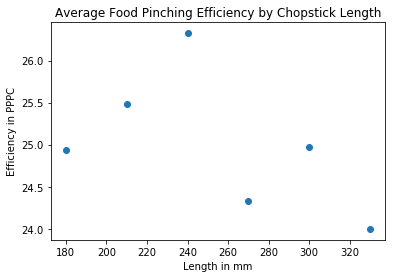

```python
# Faz gráficos aparecerem dentro do Notebook em vez de em uma nova janela
%pylab inline

import matplotlib.pyplot as plt

plt.scatter(x=meansByChopstickLength['Chopstick.Length'], y=meansByChopstickLength['Food.Pinching.Efficiency'])
            # title="")
plt.xlabel("Length in mm")
plt.ylabel("Efficiency in PPPC")
plt.title("Average Food Pinching Efficiency by Chopstick Length")
plt.show()
```

#### 6. Baseado no gráfico de dispersão criado a partir do código abaixo, interprete a relação que você vê. O que você percebe?

### No resumo, os pesquisadores estabelecem que os resultados de desempenho de pinçar comida são significativamente afetados pelo comprimento dos palitinhos, e que os palitinhos de 240 mm são ótimos para adultos.

#### 7a. Baseado nos dados que você analisou, você concorda com a afirmação?

Sim.

#### 7b. Por quê?

O gráfico de dispersão apresenta um ponto ótimo (pico) para a eficiência PPPC no valor de 240 mm.